# Homework00

#### Name: Subhankar Ghosh

#### NetID: ghosh17

## Exercise 1, Diabetes

```r
library(faraway)
library(tibble)
```

```r
data(diabetes)
diabetes_data = as_data_frame(diabetes)
diabetes_data
```

```
## # A tibble: 403 x 19
##       id  chol stab.glu   hdl ratio glyhb   location   age gender height
##  * <int> <int>    <int> <int> <dbl> <dbl>     <fctr> <int> <fctr>  <int>
##  1  1000   203       82    56   3.6  4.31 Buckingham    46 female     62
##  2  1001   165       97    24   6.9  4.44 Buckingham    29 female     64
##  3  1002   228       92    37   6.2  4.64 Buckingham    58 female     61
##  4  1003    78       93    12   6.5  4.63 Buckingham    67   male     67
##  5  1005   249       90    28   8.9  7.72 Buckingham    64   male     68
##  6  1008   248       94    69   3.6  4.81 Buckingham    34   male     71
##  7  1011   195       92    41   4.8  4.84 Buckingham    30   male     69
##  8  1015   227       75    44   5.2  3.94 Buckingham    37   male     59
##  9  1016   177       87    49   3.6  4.84 Buckingham    45   male     69
## 10  1022   263       89    40   6.6  5.78 Buckingham    55 female     63
## # ... with 393 more rows, and 9 more variables: weight <int>,
## #   frame <fctr>, bp.1s <int>, bp.1d <int>, bp.2s <int>, bp.2d <int>,
## #   waist <int>, hip <int>, time.ppn <int>
```

There are 403 observations(403 rows). There are 19 variables(19 columns). THe dataset contains the following data: 403 African Americans were interviewed in a study to understand the prevalence of obesity, diabetes, and other cardiovascular risk factors in central Virginia.

```r
#Finding all columns that contain NA
colnames(diabetes_data)[colSums(is.na(diabetes_data))>0]
```

```
##  [1] "chol"     "hdl"      "ratio"    "glyhb"    "height"   "weight"
##  [7] "frame"    "bp.1s"    "bp.1d"    "bp.2s"    "bp.2d"    "waist"
## [13] "hip"      "time.ppn"
```

```r
#Since hdl contain NA values therefore the parameter na.rm = TRUE
mean(diabetes_data$hdl, na.rm = TRUE)
```

```
## [1] 50.44527
```

```r
mean(diabetes_data[diabetes_data$gender == "female", "hdl"][[1]], na.rm = TRUE)
```

```
## [1] 52.11111
```

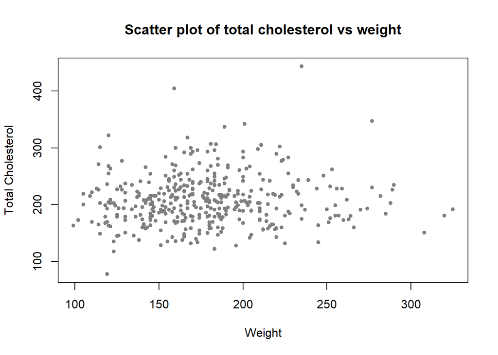

```r
plot(x = diabetes_data$weight, y = diabetes_data$chol, xlab = "Weight", ylab = "Total Cholesterol", main = "Scatter plot of total cholesterol vs weight", cex = 0.7, pch = 19, col = "grey50")
```

- From the above plot between Total Cholesterol and Weight we cannot determine any relationship between the variables.
- The total cholesterol variable seems to be distributed uniformly across weight, and we do not see any kind of trend of change of cholesterol with the change in weight.
- Like we see total cholesterol varying between 100 to 300 for any range of weights, except some outliers (around 400 and above).

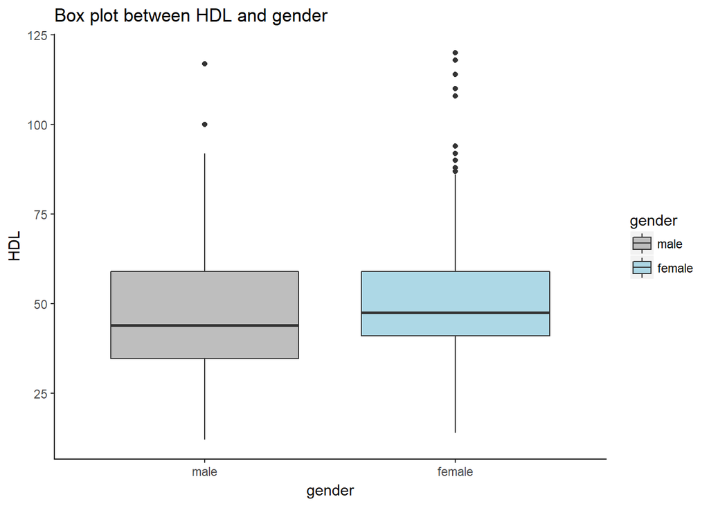

```r
library(ggplot2)
ggplot(subset(diabetes_data, !is.na(hdl)), aes(y = hdl, x = gender, fill = gender)) + geom_boxplot() + ylab("HDL") + ggtitle("Box plot between HDL and gender") + scale_fill_manual(breaks = c("male", "female"), values = c("grey", "light blue")) + theme(panel.background = element_rect(fill = "white"), axis.line.x = element_line(color = "black", linetype = "solid", size = 0.5), axis.line.y = element_line(color = "black", linetype = "solid", size = 0.5))
```

Based on the box plots it is seen that:

- In males the HDL level is more spread out (The 1st quartile is around 34 and the 3rd quartile is around 59 for males)
- For females it is less spread out (The 1st quartile is around 41 and the 3rd quartile is around 59 for females).
- We can also see the median hdl for females is higher than that of males.

### Exercise 2

```r
nutrition = read.csv(file = "nutrition.csv")
nutrition = as_data_frame(nutrition)
nutrition
```

```
## # A tibble: 5,138 x 15
##       ID                                               Desc Water Calories
##    <int>                                             <fctr> <dbl>    <int>
##  1 13320        BEEF,VAR MEATS&BY-PRODUCTS,BRAIN,CKD,SIMMRD 74.86      151
##  2 13318               BEEF,VAR MEATS&BY-PRODUCTS,BRAIN,RAW 76.29      143
##  3 17357              LAMB,NZ,IMP,BRAINS,CKD,SOAKED & FRIED 73.11      154
##  4  1137                                     EGG,YOLK,DRIED  3.08      669
##  5 17358                             LAMB,NZ,IMP,BRAINS,RAW 78.52      118
##  6  1133                                      EGG,WHL,DRIED  2.78      592
##  7  1125                                  EGG,YOLK,RAW,FRSH 52.31      322
##  8 23421 BEEF,NZ,IMP,VAR MEATS & BY-PRODUCTS,KIDNEY,CKD,BLD 66.44      157
##  9  1126                              EGG,YOLK,RAW,FRZ,PAST 56.44      296
## 10  1127                      EGG,YOLK,RAW,FRZ,SUGARED,PAST 51.23      307
## # ... with 5,128 more rows, and 11 more variables: Protein <dbl>,
## #   Fat <dbl>, Carbs <dbl>, Fiber <dbl>, Sugar <dbl>, Calcium <int>,
## #   Potassium <int>, Sodium <int>, VitaminC <dbl>, Chol <int>,
## #   Portion <fctr>
```

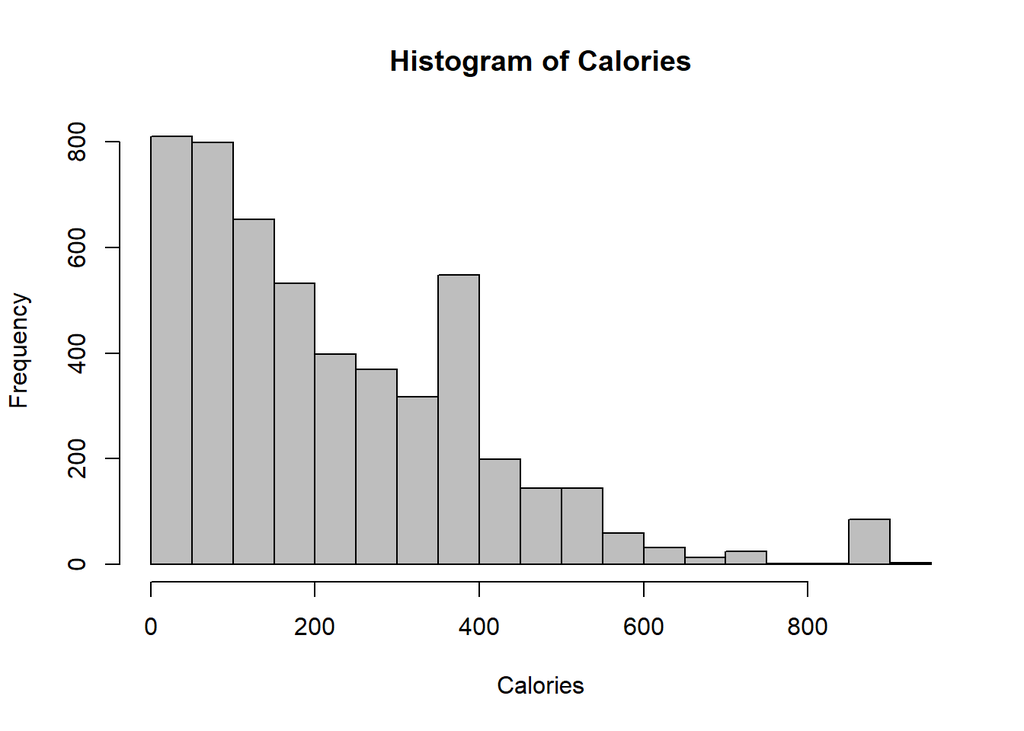

```r
hist(nutrition$Calories, xlab = "Calories", main = "Histogram of Calories", col = "grey")
```

- The histogram is right skewed. The number of low calorie food items are more than the number of high calorie food.
- The number of food items in each bin goes down as the calories increase. Except at one place (Calorie 350 -400)
- One observation is that there is a spike at two places calories content 350-400 and 850-900.

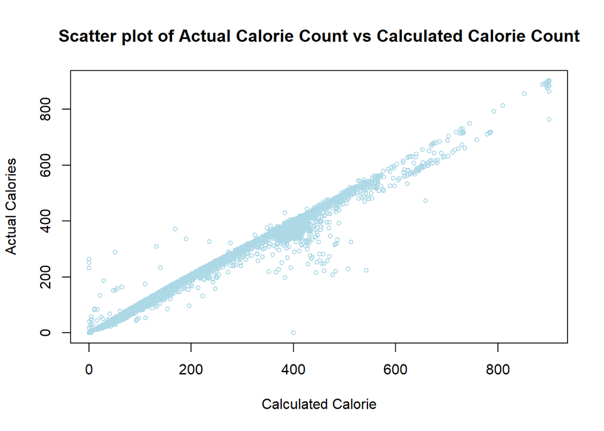

```r
nutrition$NewX = 4 * nutrition$Protein + 4 * nutrition$Carbs + 9 * nutrition$Fat + 2 * nutrition$Fiber
plot(x = nutrition$NewX, y = nutrition$Calories, xlab = "Calculated Calorie", ylab = "Actual Calories", main = "Scatter plot of Actual Calorie Count vs Calculated Calorie Count", col = "light blue", cex = 0.7)
```

- The result is almost a straight line as expected but there are some points which do not lie on the straight line.
- The variation can be due to two reasons
  - Actual random error of the model $Y = \beta X + e$ where the $e$ is the error of the actual model, this is the random component of the model.
  - The residual error in estimating the coefficients of the linear regression model. $\hat{e} = Y - \hat{Y}$, where $\hat{Y}$ is the fitted calorie value and $Y$ the actual calorie value.

### Exercise 3

```r
a = 1:10
b = 10:1
c = rep(1, times = 10)
d = 2 ^ (1:10)
```

```r
sum_of_squares = function(x)
{
  sum(x ^ 2)
}

sum_of_squares(x = a)
```

```
## [1] 385
```

```r
sum_of_squares(x = c(c, d))
```

```
## [1] 1398110
```

```r
rms_diff = function(x, y)
{
  n = max(length(x), length(y))
  sqrt(sum((x - y)^2)/n)
}

rms_diff(x = a, y = b)
```

```
## [1] 5.744563
```

```r
rms_diff(x = d, y = c)
```

```
## [1] 373.3655
```

```r
rms_diff(x = d, y = 1)
```

```
## [1] 373.3655
```

```r
rms_diff(x = a, y = 0) ^ 2 * length(a)
```

```
## [1] 385
```